# [WUM] Projekt 2 - Customers' credit cards data

### Hubert Baniecki, Mateusz Polakowski

Zadanie klasteryzacji opiera się na zbiorze pochodzącym ze strony *Kaggle* ([link](https://www.kaggle.com/arjunbhasin2013/ccdata)), który zawiera zanonimizowane informacje podsumowujące płatności właścicieli kart kredytowych. Dokładny opis posiadanych kolumn:

- **BALANCE** : Stan konta użytkownika
- **BALANCE_FREQUENCY** : Jak często stan konta jest aktualizowany (wartości od 1 do 0, gdzie 1 to bardzo często, 0 bardzo rzadko)
- **PURCHASES** : Suma płatności dokonanych z konta
- **ONEOFF_PURCHASES** : Maksymalna jednorazowa płatność
- **INSTALLMENTS_PURCHASES** : Płatności w ratach
- **CASH_ADVANCE** : Wpłata podstawowa użytkownika
- **PURCHASES_FREQUENCY** : Jak często użytkownik dokonuje płatności
- **ONEOFFPURCHASESFREQUENCY** : Jak często zdarzają się płatności jednorazowe
- **PURCHASESINSTALLMENTSFREQUENCY** : Jak często zdarzają się płatności w ratach
- **CASHADVANCEFREQUENCY** : Jak często zdarzają się wypłaty pieniędzy (kredyt gotówkowy)
- **CASHADVANCETRX** : Liczba wypłat pieniędzy (kredyt gotówkowy)
- **PURCHASES_TRX** : Liczba dokonanych transakcji/płatności
- **CREDIT_LIMIT** : Limit karty kredytowej użytkownika
- **PAYMENTS** : Liczba dokonanych płatności
- **PRCFULLPAYMENT** : Procent pełnej płatności uiszczonej przez użytkownika
- **TENURE** : Czas trwania aktywnej karty kredytowej użytkownika

Analiza skupień w takim przypadku może mieć znaczenie w planowaniu strategii banków, wyszczególniania grup klientów cechujących się podobnym podejściem do bankowości, czy tworzeniu nowych akcji promocyjnych.

## Uzupełnienie do EDA

### Histogramy niektórych zmiennych po przekształceniach

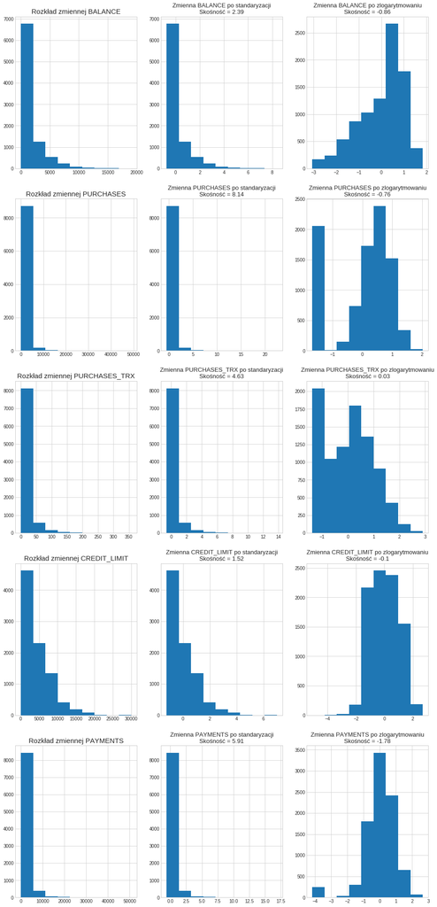

### Redukcja wymiarów

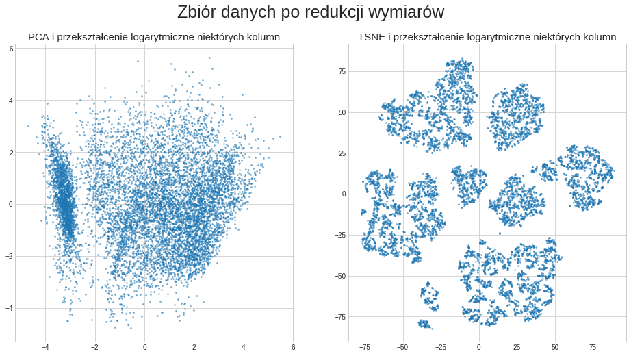

## Analiza skupień

### Agglomerative clustering

Jako pierwszy wypróbowaliśmy algorytm hierarchiczny, próbowaliśmy znaleźć jak najlepszą liczbe klastrów.

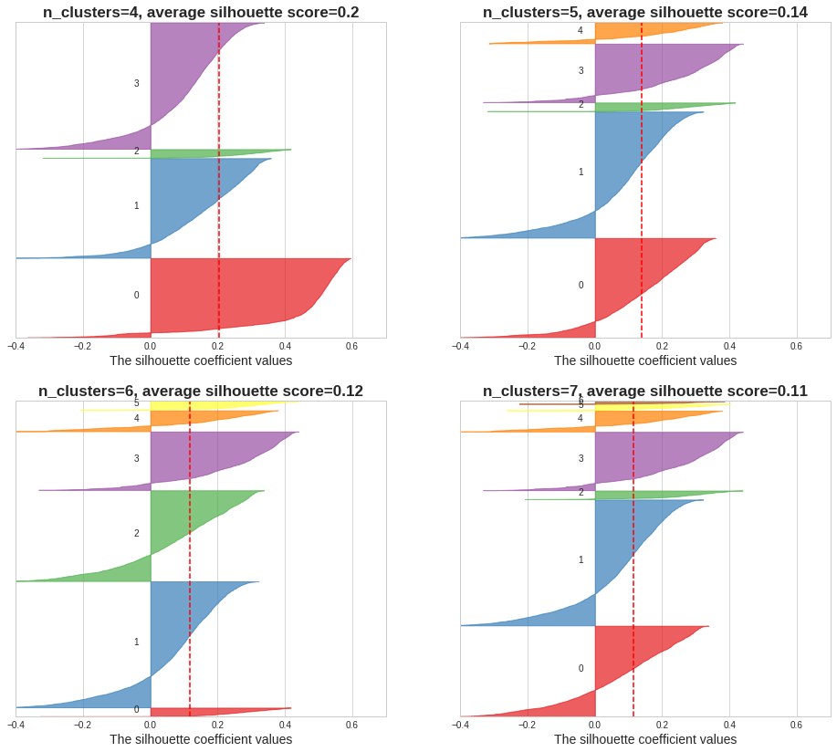

W tym przypadku zbadajmy dokładniej liczbę klastrów równą $4$:

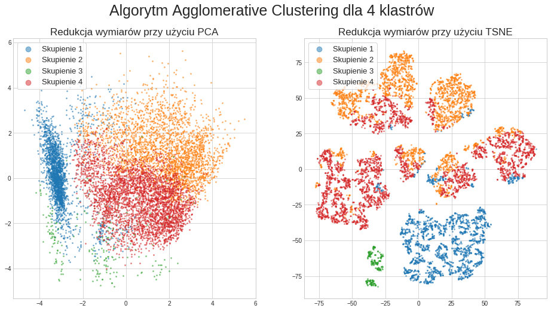

Jak widać, nawet dla najlepszej liczby klastrów nie ma sensownych efektów.

### DBSCAN - algorytm gęstościowy

Drugim testowanym algorytmem jest *DBSCAN*, który ma nieco odmienne podejście do problemu analizy skupień. Dzięki niemu jesteśmy w stanie stwierdzić, czy w naszym zbiorze danych występują gęste skupiska rekordów.

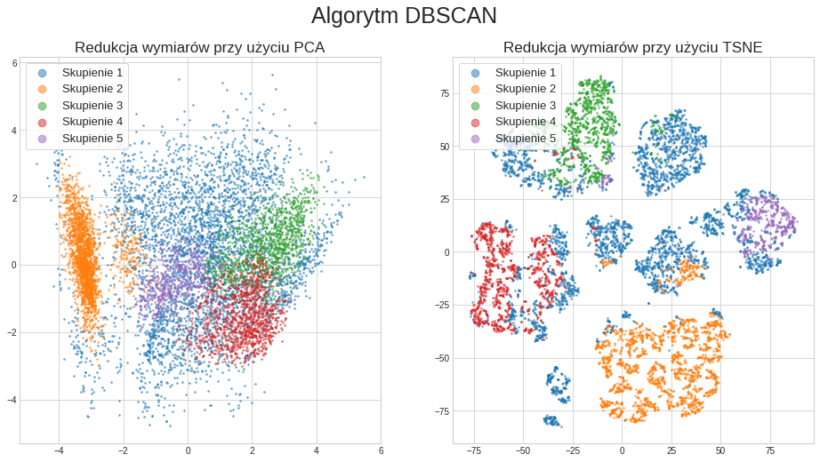

Algorytm ten wskazał nam wyróżniające się 4 grupy w naszym zbiorze danych, widoczne przede wszystkim na TSNE.

### Elbow plot

Szukamy najbardziej trafnej liczby klastrów rysując *elbow plot* - wykres, który wskazuje łączną sumę kwadratów odległości punktów od środków swoich klastrów (wykorzystamy do tego algorytm *k-średnich*)

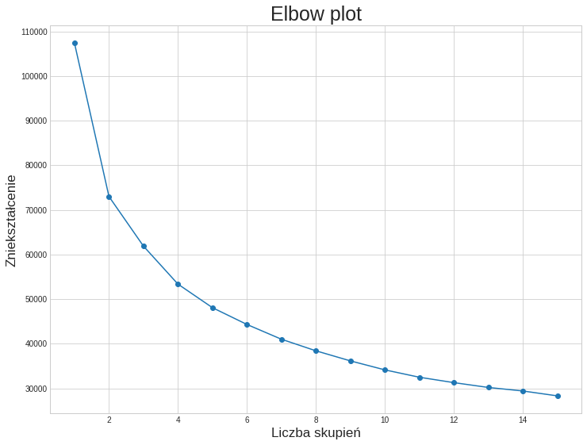

### Miara silhouette

Zbadaliśmy też dla jakiej liczby klastrów osiągniemy najlepszy wynik miary silhouette.

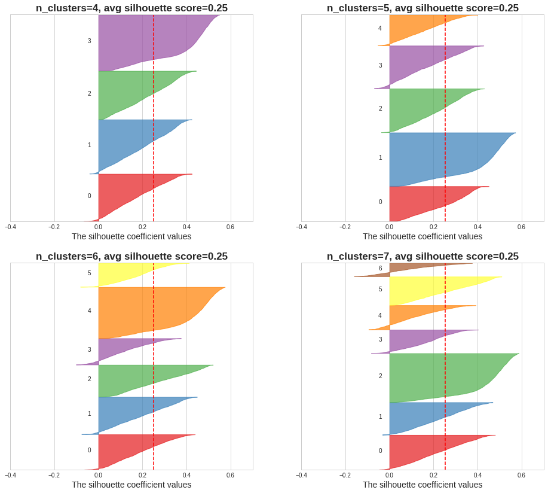

### Końcowy model

Mimo, że średni wynik analizy profilu wychodzi ten sam we wszystkich przypadkach, to zbadajmy dokładniej liczbę klastrów równą $5$:

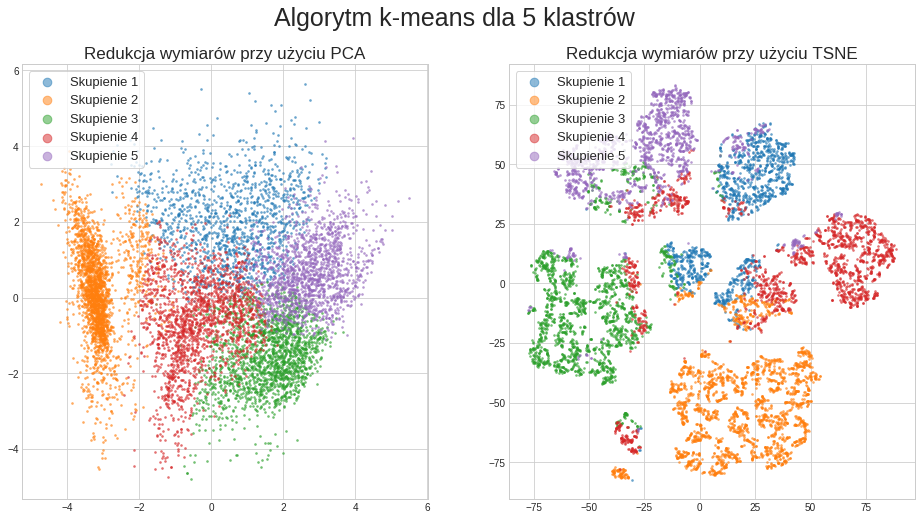

Na powyższych wykresach możemy zaobserwować to, co starał się przekazać nam algorytm DBSCAN.

## Biplot dla 5 klastrów

[figure not shown]

## PCA w 3D

[Wizualizacja naszego zbioru przy użyciu *TensorBoard*](https://projector.tensorflow.org/?config=https://gist.githubusercontent.com/hbaniecki/c510150e38a6518bae1b0d52d0f96a2b/raw/599e5f97e2912c8e81a3d563ab5bd3fd5165ace9/template_projector_config.json)

## Wnioski

- Wbrew pozorom zadanie klasteryzacji na takich zbiorach nie jest trywialne
- Algorytm *agglomerative clustering* łącząc klastry ze sobą może dawać niekoniecznie celne wyniki
- Algorytm *DBSCAN* ukazując największe skupienia w zbiorze może jako jedyny pokazywać faktyczne grupy docelowe
- Algorytm *K-means* stanowi uzupełnienie klastrów wskazanych przez *DBSCAN*
- *Tensorboard* robi fajne wizualizacje